# **Algoritma Insertion Sort**

Pada algoritma insertion sort, diasumsikan bahwa sebagian data sudah dalam keadaan terurut (pada posisi sebelah kiri dari data list), sehingga data berikutnya akan dibandingkan dengan data yang sudah dalam keadaan terurut ini, dan **disisipkan (insertion)** pada bagian data yang sudah terurut tersebut. Dengan konsep seperti ini, posisi sebelah kiri dari list data (sebelum ada data baru yang akan disisipkan), selalu dalam keadaan terurut.

Berikut algoritma Insertion Sort :

Insertion sort adalah algoritma pengurutan sederhana yang bekerja dengan cara memasukkan setiap elemen dari daftar yang belum diurutkan secara iteratif ke posisi yang benar dalam bagian daftar yang sudah diurutkan. Ini seperti mengurutkan kartu remi di tangan Anda. Anda membagi kartu menjadi dua kelompok: kartu yang sudah diurutkan dan kartu yang belum diurutkan. Kemudian, Anda mengambil kartu dari kelompok yang belum diurutkan dan meletakkannya di tempat yang tepat dalam kelompok yang sudah diurutkan.

- Mulailah dengan elemen kedua karena elemen pertama diasumsikan sudah terurut.
- Bandingkan elemen kedua dengan elemen pertama; jika elemen kedua lebih kecil, tukar posisinya.
- Pindah ke elemen ketiga, bandingkan dengan dua elemen pertama, dan letakkan pada posisi yang benar.
- Ulangi hingga seluruh array terurut.

**Iterasi Pertama.** Pada iterasi pertama, diasumsikan indeks ke-0, adalah data yang sudah dalam keadaan terurut. Data yang digunakan sebagai **key**, adalah data indeks ke-1. Langkah berikutnya adalah menyisipkan key pada kumpulan data terurut sebelumnya, sehingga data saat ini menjadi [2.5, 7, 5, 10, 1]. Akhir dari iterasi pertama adalah, data pada indeks ke-0 dan indeks ke-1, sudah dalam keadaan terurut. Ilustrasi ini dapat dilihat pada Gambar 1.

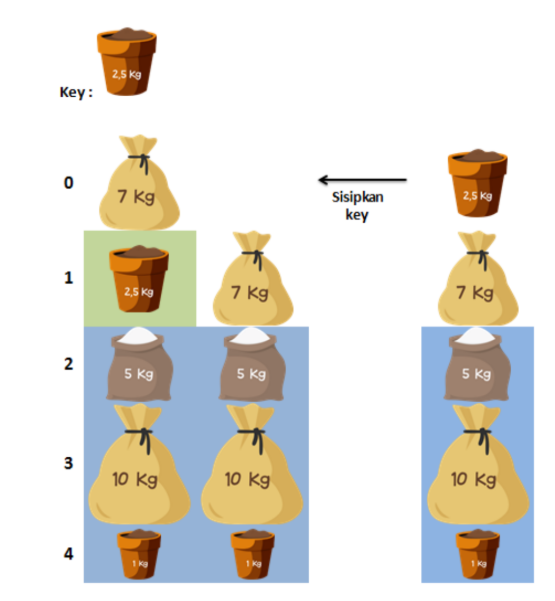

**Gambar 1. Iterasi Pertama Algoritma Insertion Sort**

**Iterasi Kedua.** Pada iterasi kedua menjadikan data pada indeks ke-2, yaitu 5, menjadi key. Sehingga pada iterasi kedua ini, berusaha menyispikan key pada kumpulan data terurut sebelumnya, yaitu [2.5, 7], dengan cara membandingkan satu persatu. Karena nilai key lebih kecil dari 7, dan lebih besar dari 2.5, maka key disisipkan diantara kedua nilai tersebut, sehingga data setelah iterasi kedua, menjadi [2.5, 5, 7, 10, 1]. Dapat dilihat bahwa data indeks ke-0, sampai dengan indeks ke-2, sudah dalam keadaan terurut. Ilustrasi ini dapat dilihat pada Gambar 2.

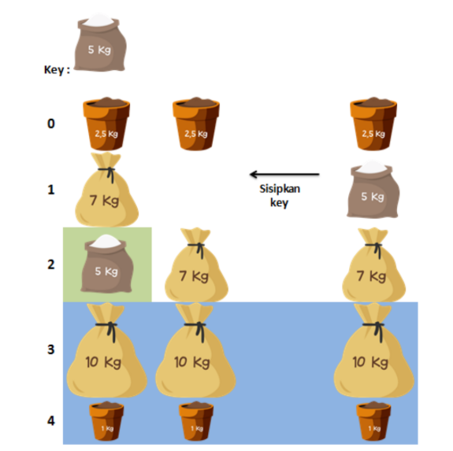

**Gambar 2. Iterasi Kedua Algoritma Insertion Sort**

**Iterasi Ketiga.** Key pada iterasi ketiga adalah data pada indeks ke-3, yaitu 10. Tujuan akhir dari iterasi ketiga adalah mencari lokasi yang tepat untuk data 10 diantara data yang sudah urut sebelumnya, yaitu [2.5, 5, 7]. Karena perbandingan pertama yang dilakukan adalah dengan data 7, dan 10 > 7, maka data 10 berada pada tempat yang sama. Ilustrasi iterasi ketiga ini, dapat dilihat pada Gambar 3.

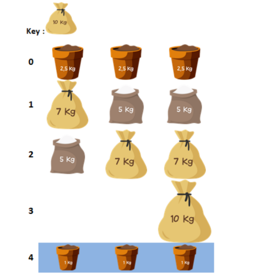

**Gambar 3. Iterasi Ketiga Algoritma Insertion Sort**

**Iterasi Keempat.** Key untuk iterasi keempat adalah data pada indeks ke-4, yaitu 1. Pada iterasi keempat ini bertujuan untuk menyisipkan data 1 pada data yang sudah dalam keaadan urut sebelumnya, yaitu [2.5, 5, 7, 10]. Perbandingan dilakukan sebanyak empat kali untuk mencari posisi yang tepat untuk data 1 ini. Sehingga data 1 harus disisipkan, sebelum data 2.5. Ilustrasi ini dapat dilihat pada Gambar 4.

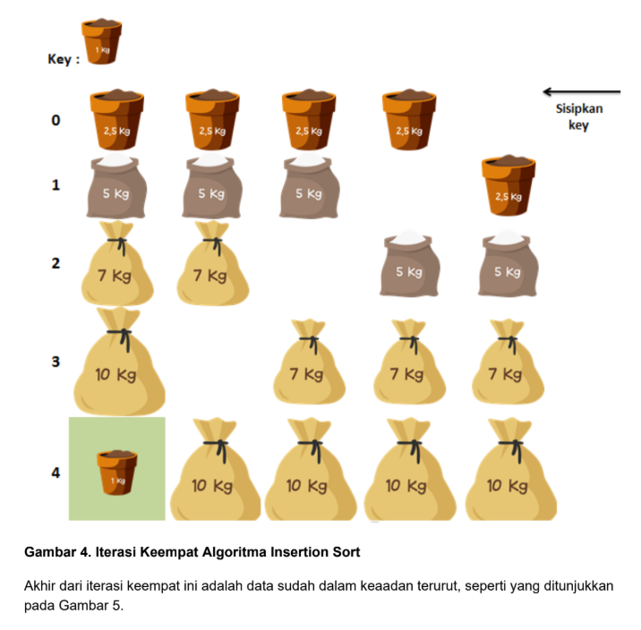

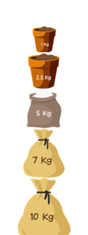